# Assignment 2

Joseph Li Wan Wang

2024-06-24

# Assignment 2

### *Joseph Li Wan Wang*

Libraries and dataset:

```r
library(foreign)
library(ggplot2)
library(lme4)

setwd("C:\\Users\\Joseph\\Desktop\\Multilevel Modelling")
dat <- read.dta("wheeze.dta", convert.factors =F)
attach(dat)
```

### 1. Describe the data situation (i.e. which variables were measured and how are the levels defined). [1 pt.]

The dataset includes 5 vector columns

1. **id**: Child identifier
   - **Type**: Categorical
   - **Description**: A unique identifier for each child in the dataset
2. **age**: Number of years since the ninth birthday
   - **Type**: Ordinal
   - **Description**: Represents the child’s age at the time of measurement. It ranges from -2 (7 years old) to 1 (10 years old)
3. **smoking**: Smoking status of the mother
   - **Type**: Binary
   - **Description**: A dicotomous variable indicating whether the mother of the child smokes regularly (1 = yes, 0 = no).
4. **y**: Wheeze status
   - **Type**: Binary
   - **Description**: Indicates whether the child is experiencing wheezing at the time of measurement (1 = yes, 0 = no)
5. **var**: Time-point of data measurement
   - **Type**: Ordinal
   - **Description**: The Time-points of data measurement coded from 2 to 5. It is ignored since the variable age served the same purpose

The dataset is defined at two nested levels:

1. **Level 1 (within-child level)**: Repeated measures that may vary over time for each child.
   - Variables at this level: `age` and `y`.
2. **Level 2 (between-child level)**: Includes variables that are constant for each child across timepoints.
   - Variables at this level: `id` and `smoking`.

### 2. Formulate a model based on these four operationalized alternative hypotheses

- H1 The intercept variance is different from zero.
- H2 The slope variance is different from zero.
- H3 The fixed effect of age on wheezing is different from zero.
- H4 The fixed effect of smoking on wheezing is different from zero.

#### (a) Describe how you want to test the hypotheses using a top-down procedure. Explain the rationale behind the top-down procedure. Include in you description the terms “likelihood ratio test”, “nested model”, and “parsimony”. [2 pts.]

To test the hypotheses using a top-down procedure, we start by fitting the most complex model that includes all potential fixed (age and maternal smoking + interaction) and random (intercept and slope) effects.

This complex model represents the “Top” in the Top-Down approach. Therefore, we will compare it with simpler models that do not include some of those effects (Those models are nested into the more complex model). If the model fit, which is evaluated by using implementations such as the likelihood ratio test does not differ significantly in favour of the more complex model, or is significantly better for the simpler model, we will choose the simpler model. We will always tend to choose the simpler models because we follow the principle of parsimony, meaning that we want to take as few assumptions as possible for our model while still ensuring a good fit.

Taking the different hypotheses in a top-down complexity level, we would have to test in the following order: H2 > H1 > H3/H4

#### (b) Formulate the model for the most complex analysis that can be derived from your four hypotheses (i.e. the first model in a top-down procedure). Use the formulation for generalized multilevel models (i.e. the link function, the residual structure of the observed dependent variable and the linear model(s) for a latent variable). Write down the whole model. [3 pts.]

The most complex analysis that can be derived includes:

- Intercept
- Fixed effects: age, smoking and their interaction (Which isn’t mentioned in the Hypotheses but is still important)
- Random effects: Random intercept and slope for age at the within-child level

We implement it in lme4:

```r
# The most complex model:
mod_complex <- glmer(y ~ 1 + age:smoking + age + smoking + (1 + age | id), family = binomial(link = "logit"))
```

The equations of the model are such as follows:

- Link Function
  - $\eta_{it} = \text{logit}(\mu_{it})$
- Linear model for a latent variable
  - $\eta_{it} = \gamma_{00} + \gamma_{01} \text{Age}_{it} + \gamma_{10} \text{Smoking}_i + \gamma_{11} (\text{Age}_{it} \text{Smoking}_i) + u_{0i} + u_{1i} \text{age}_{it}$
- Residual structure of the observed dependent variable
  - $(y_{it} | x_{it}) \sim \text{Bernoulli}(\mu_{it})$ or $(y_{it} | x_{it}) \sim \text{Binomial}(\mu_{it})$

### 3. Run the models and provide the results, i.e. report on model fit and model difference tests in a table. Which model do you select as final model? [3 pts.]

1. **Check the model fit of our initial model:**

```r
# Most complex model for top-down refence
mod_0 <- glmer(y ~ 1 + age:smoking + age + smoking + (1 + age | id), family = binomial(link = "logit"))
summary(mod_0)
```

```
Generalized linear mixed model fit by maximum likelihood (Laplace Approximation) ['glmerMod']
 Family: binomial  ( logit )
Formula: y ~ 1 + age:smoking + age + smoking + (1 + age | id)

     AIC      BIC   logLik deviance df.resid
  1601.3   1641.1   -793.7   1587.3     2141

Scaled residuals:
     Min       1Q   Median       3Q      Max
-1.24838 -0.18153 -0.14760 -0.09758  2.18559

Random effects:
 Groups Name        Variance Std.Dev. Corr
 id     (Intercept) 7.0334   2.6520
        age         0.2536   0.5036   0.45
Number of obs: 2148, groups:  id, 537

Fixed effects:
            Estimate Std. Error z value Pr(>|z|)
(Intercept)  -3.7450     0.4285  -8.740   <2e-16 ***
age          -0.3871     0.2778  -1.393    0.164
smoking       0.5102     0.3275   1.558    0.119
age:smoking   0.1259     0.1566   0.804    0.421
---
Signif. codes:  0 ‘***’ 0.001 ‘**’ 0.01 ‘*’ 0.05 ‘.’ 0.1 ‘ ’ 1

Correlation of Fixed Effects:
            (Intr) age    smokng
age          0.299
smoking     -0.357 -0.134
age:smoking -0.188 -0.346  0.397
```

The intercept is significant, but the effects of age, maternal smoking, and their interaction are not statistically significant. This might be due to the fact that those variables have no actual predicting power or conversely, that those effects are masked by random effects. In the next step we compare with simpler nested models to ensure parsimony, starting by the **random effects:**

2. **We test the need for a random slope**

```r
# Same model but no random slope
mod_1 <- glmer(y ~ 1 + age + smoking + age:smoking + (1 | id), family = binomial(link = "logit"))

# Model comparison
anova(mod_0, mod_1)
```

```
Data: NULL
Models:
mod_1: y ~ 1 + age + smoking + age:smoking + (1 | id)
mod_0: y ~ 1 + age:smoking + age + smoking + (1 + age | id)
      npar    AIC    BIC  logLik deviance  Chisq Df Pr(>Chisq)
mod_1    5 1599.3 1627.7 -794.66   1589.3
mod_0    7 1601.3 1641.0 -793.67   1587.3 1.9668  2      0.374
```

The difference between both models is not significant, indicating that adding a random slope for age does not significantly improve the model fit. Therefore, we will prioritize the simpler model that has no random slope.

3. **We test the need for a random intercept**

```r
# Model with no random intercept
mod_2 <- glm(y ~ 1 + age + smoking + age:smoking, family = binomial(link = "logit"))

# Model comparison
anova(mod_1, mod_2)
```

```
Data: NULL
Models:
mod_2: y ~ 1 + age + smoking + age:smoking
mod_1: y ~ 1 + age + smoking + age:smoking + (1 | id)
      npar    AIC    BIC  logLik deviance  Chisq Df Pr(>Chisq)
mod_2    4 1827.5 1850.2 -909.74   1819.5
mod_1    5 1599.3 1627.7 -794.66   1589.3 230.17  1  < 2.2e-16 ***
---
Signif. codes:  0 ‘***’ 0.001 ‘**’ 0.01 ‘*’ 0.05 ‘.’ 0.1 ‘ ’ 1
```

The difference between both models is significant, indicating that adding a random intercept significantly improves the model fit. Therefore, we will choose model nº 1. Nextly we will test the **fixed effects:**

4. **We test the need for a interaction effect**

```r
# Model 1 without interaction effect
mod_3 <- glmer(y ~ 1 + age + smoking + (1 | id), family = binomial(link = "logit"))

# Model comparison
anova(mod_1, mod_3)
```

```
Data: NULL
Models:
mod_3: y ~ 1 + age + smoking + (1 | id)
mod_1: y ~ 1 + age + smoking + age:smoking + (1 | id)
      npar    AIC    BIC  logLik deviance  Chisq Df Pr(>Chisq)
mod_3    4 1597.9 1620.6 -794.94   1589.9
mod_1    5 1599.3 1627.7 -794.66   1589.3 0.5659  1     0.4519
```

The difference between both models is not significant, indicating that adding an interaction between age and smoking does not significantly improve the model fit. Therefore, we will prioritize the simpler model that has no interaction.

5. **We test the basic fixed effects (age and smoking)**

```r
# Model that ignores the fixed effect of age
mod_4 <- glmer(y ~ 1 + smoking + (1 | id), family = binomial(link = "logit"))

# Model comparison
anova(mod_3, mod_4)
```

```
Data: NULL
Models:
mod_4: y ~ 1 + smoking + (1 | id)
mod_3: y ~ 1 + age + smoking + (1 | id)
      npar    AIC    BIC  logLik deviance  Chisq Df Pr(>Chisq)
mod_4    3 1602.7 1619.8 -798.37   1596.7
mod_3    4 1597.9 1620.6 -794.94   1589.9 6.8612  1   0.008809 **
---
Signif. codes:  0 ‘***’ 0.001 ‘**’ 0.01 ‘*’ 0.05 ‘.’ 0.1 ‘ ’ 1
```

```r
# Model that ignores the fixed effect of smoking
mod_5 <- glmer(y ~ 1+ age + (1 | id), family = binomial(link = "logit"))

# Model comparison
anova(mod_3, mod_5)
```

```
Data: NULL
Models:
mod_5: y ~ 1 + age + (1 | id)
mod_3: y ~ 1 + age + smoking + (1 | id)
      npar    AIC    BIC  logLik deviance  Chisq Df Pr(>Chisq)
mod_5    3 1598.0 1615.0 -795.98   1592.0
mod_3    4 1597.9 1620.6 -794.94   1589.9 2.0883  1     0.1484
```

The improvement in model fit is significant for age, but not for smoking. Therefore, we could choose the model that only includes age. However, the benefits would be really small, and we would be refusing a key regressor which is very relevant at a theoretical level. Hence, it could be reasonable to keep smoking into the model for practical reasons.

```r
mod = mod_3
```

### 4. Refer to the hypotheses you formulated above and interpret them with regard to the content. Use the odds ratios for the fixed effects. [4 pts.]

Firstly, we will look at the summary of the chosen model:

```r
summary(mod)
```

```
Generalized linear mixed model fit by maximum likelihood (Laplace Approximation) ['glmerMod']
 Family: binomial  ( logit )
Formula: y ~ 1 + age + smoking + (1 | id)

     AIC      BIC   logLik deviance df.resid
  1597.9   1620.6   -794.9   1589.9     2144

Scaled residuals:
    Min      1Q  Median      3Q     Max
-1.4027 -0.1802 -0.1577 -0.1321  2.5176

Random effects:
 Groups Name        Variance Std.Dev.
 id     (Intercept) 5.491    2.343
Number of obs: 2148, groups:  id, 537

Fixed effects:
            Estimate Std. Error z value Pr(>|z|)
(Intercept) -3.37396    0.27493 -12.272   <2e-16 ***
age         -0.17677    0.06797  -2.601   0.0093 **
smoking      0.41478    0.28701   1.445   0.1484
---
Signif. codes:  0 ‘***’ 0.001 ‘**’ 0.01 ‘*’ 0.05 ‘.’ 0.1 ‘ ’ 1

Correlation of Fixed Effects:
        (Intr) age
age      0.227
smoking -0.419 -0.010
```

We can observe a substantial random intercept associated to the child level with a variance of 5,491. Which means that each child has their own baseline level of wheezing risk, accounting for heterogeneity between children. Having this random intercept at the child level makes sense because we expect children to have characteristics that remain constant across time and make the within-child observations be mutually correlated.

**Next, we will take a closer look at the fixed effects and the odds ratios:**

```r
# We look for the fixed effects estimates
b1 <- fixef(mod)
# Parameter interpretation by calculating Odds ratios
round(exp(b1),3)
```

```
(Intercept)         age     smoking
      0.034       0.838       1.514
```

- **intercept:** The baseline odds of wheezing for children when age and maternal smoking are at their reference levels (no smoking and 9 years old) are 0,034.
- **Age:** For every additional year that passes for a child, the odds of wheezing decrease by a factor of 0,838, indicating a decrease in wheezing as time passes.
- **Smoking:** The odds of wheezing for children of mothers who smoke are 1,514 times the odds for children of non-smoking mothers.

### 5. Illustrate the average predicted probability for wheezing as a function of age and maternal smoking status (with estimates from your final model). Include, describe, and interpret the figure. [2 pts.]

```r
# Random effects from the final model
u0 <- ranef(mod)$id$`(Intercept)`
b1
```

```
(Intercept)         age     smoking
 -3.3739644  -0.1767670   0.4147782
```

```r
# Predicted fx
yhat1 <- function(x,smoking,u0){(exp(b1[1] + b1[2]*x + b1[3]*smoking + u0) / (1 + exp(b1[1] + b1[2]*x + b1[3]*smoking + u0)))}

# support for illustration
mtreat <- c()
patient <- as.factor(id)

for(j in 1:length(levels(patient))){mtreat[j] <- mean(smoking[patient==levels(patient)[j]])}

mean(u0[mtreat==0])
```

```
[1] 0.4468311
```

```r
mean(u0[mtreat==1])
```

```
[1] 0.4300038
```

```r
curve(yhat1(x,smoking=0,u0=mean(u0[mtreat==0])),
      ylim=c(0,0.2),xlim=c(-2,1),
      xlab="Age",add=F, ylab="Wheezing probability")
curve(yhat1(x,smoking=1,u0=mean(u0[mtreat==1])),
      xlab="Age",add=T,col="red")
```

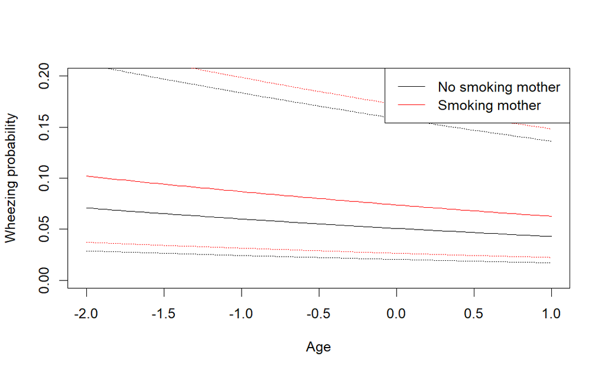

```r
colo <- c("black","red")
for(j in 1:2000){curve(yhat1(x,smoking=mtreat[j],u0=u0[j]),col=colo[mtreat[j]+1],add=T,lty="dotted")}

legend("topright",
       col=c("black","red"),
       c("No smoking mother","Smoking mother"),
       lty="solid")
```

#### Interpretation:

- **Age Effect**: As age increases, the probability of wheezing decreases. This is a general trend consistent across all conditions and at any time point
- **Effect of Maternal Smoking:** Across all ages, children of mothers who smoke (red line) have a higher probability of wheezing compared to children of non-smoking mothers (black line). However, we can observe on the dotted lines that the variance of the individual values is high and they can overlap sometimes, explaining our previous non-significant output.
- **Random intercept:** The high distance between the upper and lower dotted lines indicate the variability in baseline chances of wheezing that are independent from factors that are included in the model. Showing that some children have inherently higher or lower risks of wheezing with respect to the mean, regardless of age and maternal smoking status.

#### Summary

- The figure shows how both age and maternal smoking influence the probability of wheezing. Specifically, maternal smoking increases the risk, while aging reduces it.
- Including a random intercept into the model allows us to see how variable the baseline probability is. Investigating new variables that might capture this unexplained variability could be useful in the future.
- In general, a policy aimed to reduce maternal smoking could be helpful to alleviate this medical condition among others.